# Tercer Trabajo para el curso de Técnicas en Aprendizaje Estadístico

## Integrantes:

- Julián Alejandro Usuga Ortiz
- Santiago Campos Giraldo
- Juan José Hurtado Álvarez
- Santiago Poveda Grajales
- Diego de Oliveira Hitzges

# Planteamiento del Problema

En este trabajo nuestro objetivo es clasificar e indentificar imagenes de personas que tienen (o no) gafas.

Para esto hemos sido proporcionados una base de datos con estas imagenes.

El acercamiento que le dimos a este problema está descrito en las siguientes celdas.

```python
from google.colab import drive
drive.mount('/content/drive')
```

## Preprocesamiento

Se cargan las librerías

```python
from tqdm import tqdm
import re
import os
import cv2
import matplotlib
import matplotlib.pyplot as plt
import numpy as np
import pandas as pd
import seaborn as sns
import glob
import pickle
import random
from sklearn.metrics import accuracy_score, confusion_matrix, f1_score, precision_score, recall_score,roc_auc_score
from sklearn.model_selection import train_test_split
from sklearn.neural_network import MLPRegressor
from sklearn.metrics import mean_squared_error
from sklearn.metrics import r2_score
from sklearn.metrics import confusion_matrix
from sklearn.metrics import classification_report
from sklearn.tree import DecisionTreeClassifier
from sklearn import metrics
from sklearn.metrics import accuracy_score
from sklearn.model_selection import cross_val_score
import matplotlib.pyplot as plt
from sklearn import svm
from sklearn.linear_model import LogisticRegression
from sklearn.neural_network import MLPClassifier
import warnings
warnings.filterwarnings('ignore')
seed= 0
```

Observamos la cantidad de imágenes con las que vamos a trabajar

```python
filenames = glob.glob("drive/MyDrive/Colab Notebooks/faces_4/*/*.pgm")

f"Numero de imagenes: {len(filenames)}"
```

```
'Numero de imagenes: 624'
```

Posteriormente se crea una lista de imágenes, donde se guardarán las imágenes cargadas como un Numpy-array. Para darles un mejor manejo, se les aplana para que queden como una simple fila, la cual se etiqueta adicionalmente con 1 si hace referencia desde su nombre a una persona con gafas ó 0 si la persona no las posee y finalmente se añaden una a una a la lista de Imágenes "images".

```python
#we create a list containing all the images as numpy array
images = []
for file in tqdm(filenames):
  #load images as numpy-arrays
	img = cv2.imread(file,-1)
  #flatten the arrays
	img = img.flatten()

  #add label at the end of the array: 1 for sunglass, 0 else
	if "sunglasses" in file:
		img = np.append(img,1)
	else:
		img = np.append(img,0)

  #add array to list of images
	images.append(img)
```

```python
data= np.array(images)
```

```python
data.shape
```

```
(624, 961)
```

```python
X= data[:, :-1]
X.shape
```

```
(624, 960)
```

Se normaliza los datos de X

```python
X_mean = np.mean(X, axis=1).reshape(X.shape[0],1)
X_std = np.std(X, axis=1).reshape(X.shape[0],1)
X = (X - X_mean) / X_std
X.shape
```

```
(624, 960)
```

```python
Y = data[:,-1]
Y.shape
```

```
(624,)
```

Se particionan los datos utilizando la función train_test_split de sklearn

```python
X_train, X_test, y_train, y_test = train_test_split(
  X, Y, test_size=0.2, random_state=1, stratify=Y
)

print(f'Dimensiones de "X_train": {X_train.shape}')
print(f'Dimensiones de "X_test": {X_test.shape}')
print(f'Dimensiones de "y_train": {y_train.shape}')
print(f'Dimensiones de "y_test": {y_test.shape}')
```

```
Dimensiones de "X_train": (499, 960)
Dimensiones de "X_test": (125, 960)
Dimensiones de "y_train": (499,)
Dimensiones de "y_test": (125,)
```

## Modelos

Se cargaran varios modelos de sklearn para comparar sus métricas y usar el que nos parezca más adecuado

Función que nos ayudará a ver la matriz de confusión de una manera más elegante

```python
def plot_confusion_matrix(y_true, y_pred, classes,size,
                          normalize=False,
                          title=None,
                          cmap=plt.cm.Blues):

    if not title:
        if normalize:
            title = 'Normalized confusion matrix'
        else:
            title = 'Confusion matrix, without normalization'

    # Compute confusion matrix
    cm = confusion_matrix(y_test, y_pred)
    # Only use the labels that appear in the data

    if normalize:
        cm = cm.astype('float') / cm.sum(axis=1)[:, np.newaxis]
        print("Normalized confusion matrix")
    else:
        print('Confusion matrix, without normalization')


    target_names=['no sunglasses', 'sunglasses']

    fig, ax = plt.subplots(figsize=(size,size))
    im = ax.imshow(cm, interpolation='nearest', cmap=cmap)
    ax.figure.colorbar(im, ax=ax)
    # We want to show all ticks...
    ax.set(xticks=np.arange(cm.shape[1]),
           yticks=np.arange(cm.shape[0]),
           # ... and label them with the respective list entries
           xticklabels=target_names, yticklabels=target_names,
           title=title,
           ylabel='True label',
           xlabel='Predicted label')

    # Rotate the tick labels and set their alignment.
    plt.setp(ax.get_xticklabels(), rotation=45, ha="right",
             rotation_mode="anchor")

    # Loop over data dimensions and create text annotations.
    fmt = '.2f' if normalize else 'd'
    thresh = cm.max() / 2.
    for i in range(cm.shape[0]):
        for j in range(cm.shape[1]):
            ax.text(j, i, format(cm[i, j], fmt),
                    ha="center", va="center",
                    color="white" if cm[i, j] > thresh else "black")
    fig.tight_layout()
    return ax

import numpy as np
from sklearn.metrics import confusion_matrix
from sklearn.utils.multiclass import unique_labels
a=np.array([0,1])
```

#### DecisionTreeClassifier

Primero se usarán los árboles de decisión, que son un método de clasificación muy bueno que parte los elementos a evaluar, en este caso de tener gafas o no, para mediante secuencias de decisiones buscar ir sectorizando las características para llegar a una predicción adecuada.

```python
clf_tree = DecisionTreeClassifier(random_state=seed)

clf_tree.fit(X_train, y_train)

y_pred = clf_tree.predict(X_test)
```

```python
target_names=['no sunglasses', 'sunglasses']

print(classification_report(y_test, y_pred, target_names=target_names))
```

```
               precision    recall  f1-score   support

no sunglasses       0.84      0.83      0.83        63
   sunglasses       0.83      0.84      0.83        62

     accuracy                           0.83       125
    macro avg       0.83      0.83      0.83       125
 weighted avg       0.83      0.83      0.83       125
```

```
Confusion matrix, without normalization
```

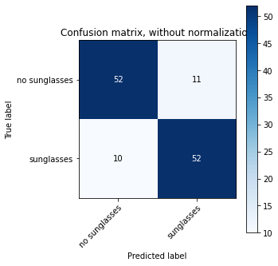

```python
plot_confusion_matrix(y_train, y_pred,a,size=5)
```

```python
clf_tree.predict((X_test[0],))
```

```
array([1])
```

Pasamos a la evaluación de este modelo, donde se puede ver como las métricas del mismo están casi todas en 83% principalmente bansándonos en el F1 score, lo que nos indica que hay un buen balance entre la precision y el recall, entonces este es un moddelo de ata calidad así mismo con buen capacidad de recibir una gran cantidad de datos.

#### Modelo con SVM sklearn

Las máquinas de soporte vectorial son modelos de redes neuronales artificiales comunmente usados para la solución de problemas de regresión y clasficación, a lo cual se ajusta al problema que buscamos solucionar

```python
clf_svm = svm.SVC(random_state=seed)

clf_svm.fit(X_train, y_train)

y_pred = clf_svm.predict(X_test)
```

```python
target_names=['no sunglasses', 'sunglasses']

print(classification_report(y_test, y_pred, target_names=target_names))
```

```
               precision    recall  f1-score   support

no sunglasses       0.88      0.84      0.86        63
   sunglasses       0.85      0.89      0.87        62

     accuracy                           0.86       125
    macro avg       0.86      0.86      0.86       125
 weighted avg       0.86      0.86      0.86       125
```

```
Confusion matrix, without normalization
```

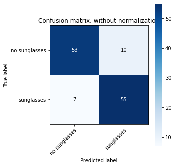

```python
plot_confusion_matrix(y_train, y_pred,a,size=5)
```

```python
clf_svm.predict((X_test[0],))
```

```
array([1])
```

### Logistic Regression

Siguiente modelo a evaluar, Regresión Logística. Generalmente es un tipo de análisis de regresión usado para clasificar variables categóricas (En nuestro caso **1 o 0** para determinar si una persona posee o no gafas en la imágen) en función de las variables predictoras. Entonces a la hora de predecir una salida discreta (Binaria, no continua), este algoritmo de aprendizaje supervisado se ajusta a la clasificación que buscamos hacer.

```python
logisticRegression = LogisticRegression(
    penalty="l2",      # ‘l1’, ‘l2’, ‘elasticnet’, ‘none’
    tol=0.0001,          # stop criteria
    C=1.0,               # factor inverso para regularizacion (SVM)
    fit_intercept=True,  #
    class_weight=None,   # None, dict or ‘balanced’
    random_state= seed,   #
    solver="sag",      # 'newton-cg’, ‘lbfgs’, ‘liblinear’, ‘sag’, ‘saga’
    max_iter=100,        #
    multi_class="auto",  # ‘ovr’, ‘multinomial’, ‘auto’
    verbose=0,           #
    warm_start=False,    # ?re-usa la solución previa
    l1_ratio=None,       # Elastic-Net mixing parameter, with 0 <= l1_ratio <= 1
)

logisticRegression.fit(X_train, y_train)

y_pred=logisticRegression.predict(X_test)
```

```python
target_names=['no sunglasses', 'sunglasses']

print(classification_report(y_test, y_pred, target_names=target_names))
```

```
               precision    recall  f1-score   support

no sunglasses       0.87      0.92      0.89        63
   sunglasses       0.91      0.85      0.88        62

     accuracy                           0.89       125
    macro avg       0.89      0.89      0.89       125
 weighted avg       0.89      0.89      0.89       125
```

```
Confusion matrix, without normalization
```

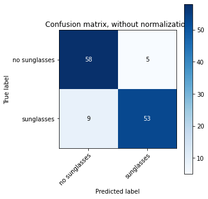

```python
plot_confusion_matrix(y_train, y_pred,a,size=5)
```

```python
logisticRegression.predict((X_test[0],))
```

```
array([1])
```

ALos resultados de la Regresión Logística si bien en precision y recall parece que la da importancia de forma inversa a las MSV, el F1 score mejoró, lo cual nos hace pensar que este método se comportó mejor que el anterior y se transforma en nuestro modelo candidato número 1.

### MLP neural_network

El perceptrón multicapa se obtiene al agrupar varios perceptrones continuos en capas para luego conectar las capas entre sí, una a continuación de la siguiente. Las neuronas de cada capa se conectan a todas y cada una de las neuronas de la siguiente capa.

```python
m = MLPClassifier(
    hidden_layer_sizes=(5,),
    random_state = seed,
    activation= "logistic",

)


m.fit(X_train, y_train)
y_pred=m.predict(X_test)
```

```python
target_names=['no sunglasses', 'sunglasses']

print(classification_report(y_test, y_pred, target_names=target_names))
```

```
               precision    recall  f1-score   support

no sunglasses       0.87      0.92      0.89        63
   sunglasses       0.91      0.85      0.88        62

     accuracy                           0.89       125
    macro avg       0.89      0.89      0.89       125
 weighted avg       0.89      0.89      0.89       125
```

```
Confusion matrix, without normalization
```

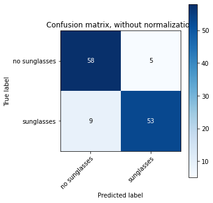

```python
plot_confusion_matrix(y_train, y_pred,a,size=5)
```

```python
m.predict((X_test[0],))
```

```
array([1])
```

Aquí aparece otro modelo candidato de muy buenos resultados, los perceptrones multicapa dieron resultados muy similares a los de la regresión logístca, donde se suma a la anteriormente mencionada como los mejores modelos.

Finalmente se decide qué modelo implementar para la clasificación final de las imágenes. Nuestros 2 modelos candidatos de mejores resultados Regresión Logística y Perceptrones multicapa, dieron resultados muy similares con los cuales a priori no se decide qué método usar. Por lo tanto teniendo en cuenta el tipo de predicción mediante etiquetas 1 y 0 y así mismo el costo computacional que es más bajo que su rival, la Regresión Logística es el algoritmo usado para esta clasificación.

## Mostrar imágenes con sus respectivas predicciones

Función para ver una imagen

```python
import re

def read_pgm(filename, byteorder='>'):
    """Return image data from a raw PGM file as numpy array.

    Format specification: http://netpbm.sourceforge.net/doc/pgm.html

    """
    if ("sunglasses" in filename): print("True label: Gafas")
    else: print("True label: No gafas")

    with open(filename, 'rb') as f:
        buffer = f.read()
    try:
        header, width, height, maxval = re.search(
            b"(^P5\s(?:\s*#.*[\r\n])*"
            b"(\d+)\s(?:\s*#.*[\r\n])*"
            b"(\d+)\s(?:\s*#.*[\r\n])*"
            b"(\d+)\s(?:\s*#.*[\r\n]\s)*)", buffer).groups()
    except AttributeError:
        raise ValueError("Not a raw PGM file: '%s'" % filename)
    return np.frombuffer(buffer,
                            dtype='u1' if int(maxval) < 256 else byteorder+'u2',
                            count=int(width)*int(height),
                            offset=len(header)
                            ).reshape((int(height), int(width)))
```

Función para ver una imagen con su etiqueta real y con su predicción

*en la función hay un parámetro llamado "modelo" el cual se puede cambiar dependiendo el tipo de método a usar para la clasificación*

```python
def show_image_with_prediction(number, modelo=logisticRegression ):
  # Modelos disponibles: logisticRegression(default),  clf_tree, clf_svm, m
  if ( number >= 624 ):
    return " Fuera de rango"
  else:
    image = read_pgm(filenames[number], byteorder='<')
    foto = cv2.imread(filenames[number], -1)
    foto= foto.flatten()
    foto = (foto - X_mean[0])/ X_std[0]
    pred= modelo.predict((foto,))
    if (pred[0] ==1) :print("Predicted label: Gafas")
    else: print("Predicted label: No gafas")
    print(filenames[number])

    plt.imshow(image, plt.cm.gray)
```

#### Ejemplos

```
True label: No gafas
Predicted label: No gafas
drive/MyDrive/Colab Notebooks/faces_4/karyadi/karyadi_right_sad_open_4.pgm
```

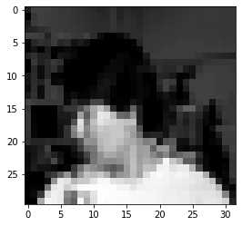

```python
show_image_with_prediction(0)
```

```
True label: No gafas
Predicted label: No gafas
drive/MyDrive/Colab Notebooks/faces_4/kawamura/kawamura_right_neutral_open_4.pgm
```

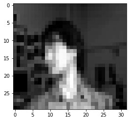

```python
show_image_with_prediction(random.randrange(623))
```

```
True label: Gafas
Predicted label: Gafas
drive/MyDrive/Colab Notebooks/faces_4/kk49/kk49_left_neutral_sunglasses_4.pgm
```

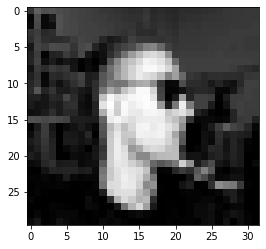

```python
show_image_with_prediction(random.randrange(623))
```

```
True label: Gafas
Predicted label: Gafas
drive/MyDrive/Colab Notebooks/faces_4/bpm/bpm_right_angry_sunglasses_4.pgm
```

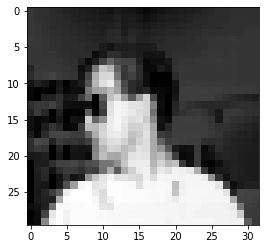

```python
show_image_with_prediction(random.randrange(623))
```

```
True label: No gafas
Predicted label: No gafas
drive/MyDrive/Colab Notebooks/faces_4/kawamura/kawamura_right_neutral_open_4.pgm
```

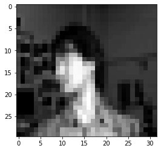

```python
show_image_with_prediction(random.randrange(623))
```

```
True label: No gafas
Predicted label: No gafas
drive/MyDrive/Colab Notebooks/faces_4/an2i/an2i_straight_angry_open_4.pgm
```

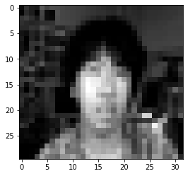

```python
show_image_with_prediction(random.randrange(623))
```

```
True label: Gafas
Predicted label: Gafas
drive/MyDrive/Colab Notebooks/faces_4/phoebe/phoebe_up_sad_sunglasses_4.pgm
```

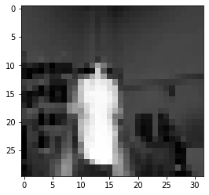

```python
show_image_with_prediction(random.randrange(623))
```

## Bibliografía

KAMBRIA. (9 de 7 de 2019). Obtenido de https://kambria.io/blog/logistic-regression-for-machine-learning/#:~:text=Logistic%20regression%20is%20a%20classification,either%20a%200%20or%201.

.

StackOverflow. (2010). Obtenido de https://stackoverflow.com/questions/7368739/numpy-and-16-bit-pgm

.

Velasquez., J. D. (2019). Redes Neuronales Artificiales y Algoritmos Bioinspirados. Obtenido de https://jdvelasq.github.io/courses/redes_neuronales_y_algoritmos_bioinspirados/index.html